# Titanic Survival Analysis

A really good friend of mine is a historian, looking to write an article about the Titanic. She has been studying the Titanic for years and knows a lot about its history. She knows a lot of facts about the infamous boat and recently got her hands into the original passenger manifest. So far, she has not been able to uncover the insights hidden in the passengers of the Titanic.

[figure not shown]

We on the other hand, are experienced data scientists, that understand data and discover useful insights, so let’s work together to find patterns of passengers that survived vs. those that pasrished. I have some gut feeling on why certain passengers survived and others perished but I would prefer to use a data driven approach. Do you think you can help me?

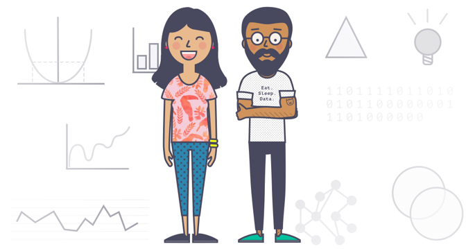

[video not shown]

A bit of history…

Everyone knows the story of the Titanic, as most of us have seen the movie by James Cameron, where Rose, a woman travelling in 1st class falls in love with Jack, a man travelling in 3rd class.

[figure not shown]

RMS Titanic was a British passenger liner that sank in the North Atlantic Ocean in the early hours of 15 April 1912, after colliding with an iceberg during her maiden voyage from Southampton to New York City.

There were an estimated 2,224 passengers and crew aboard, and more than 1,500 died, making it one of the deadliest commercial peacetime maritime disasters in modern history.

After leaving Southampton on 10 April 1912, Titanic called at Cherbourg in France and Queenstown (now Cobh) in Ireland before heading west to New York.

[figure not shown]

Let’s begin…

What is the logical first task? We have to look at the passenger manifest and see what insights we can discover. We are lucky to have access to the manifest.  
I went through the oroginal documents, and we now have a file that is ready to be used! With one line of code in R we can read this file and start exploring.

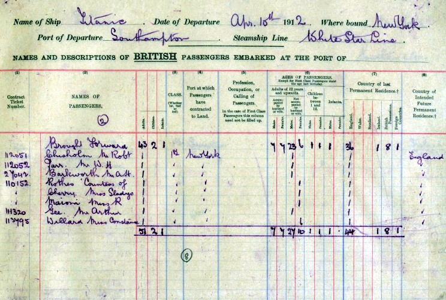

Load data

Go in the Load Data Section of your R script, highlight the code you want to execute and click ctrl+enter.

```r
original <- read.table("Data/Titanic.csv", header=T, sep=",")
```

In the screenshot shown on the right you can see that the data has been loaded. We have 891 observations and 12 variables, hence we have data for 891 passengers.

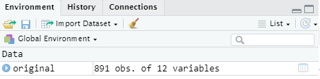

If you click on the original a new window will appear. Let’s spend a minute to explore what is in this dataset.

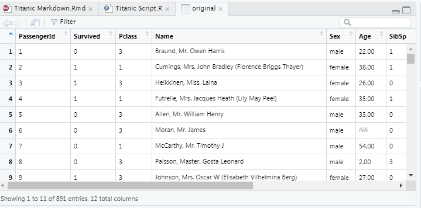

It is always good practice to look at all the headings and create what is called a data dictionary. I have already created this. Below we can find the data dictionary, that includes all 12 variables. From now on we will refer to them as features. Let’s spend some time to go though them and understand what kind of information they include. We can also start thinking which of these will be better for predicting survival.

| Feature | Definition |
| --- | --- |
| PassengerID | 1-891 |
| Survived | Survival (No=0, Yes=1) |
| PClass | Ticket Class (1, 2, 3) |
| Name | Last name and first name |
| Sex | Gender (Male, Female) |
| Age | Age (in years) |
| Sibsp | Numbers of siblings |
| Parch | Number of parents |
| Ticket | Ticket Number |
| Fare | Fare price in pounds |
| Cabin | Cabin number |
| Embarked | Port of Embarkation (C= Cherbourg, Q = Queenstown, S = Southampton) |

Data preprocessing

Great start! We now have our dataset loaded and know which are the available features. We can already decide that we want to remove some of these, as they do not have any useful informatin. We are going to remove the ticket numeber and the cabin number. Also, we look a bit closer, we will notice is that there are some missing data (NA). Missing data also does not help us to answer our question. For this reason, we will remove all observations that have missing values.

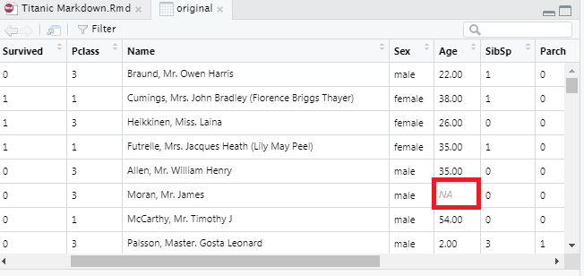

Again we can do that really easy. Let’s go to our R script. In the section Data preprocessing we will find the code as shown below. Highlight the code and press ctrl+enter.

```r
original_subset = original[,c(1,2,3,4,5,6,7,8,10,12)]
inputdata <- na.omit(original_subset)
```

A new table appeared on the right hand side of your RStudio. This is the input data that you will work with for the rest of the session. We now have 714 observations, since we have deleted all observations with missing values.

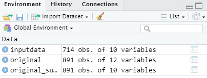

Exploratory Analytics

We have now have read our data set, removed any missing values, looked into the data dictionary and know a few more things on the passengers’ features. In order to answer our main question we have to start exploring our dataset by answering some more basic questions.  
Let’s start exploring!

[figure not shown]

Question 1: How many men and women were onboard?

Let’s try and answer this one. Again with one line of code you can easily answer this question. You can see the answer below, but you can also head back to your R script and click on the relevant chunk of code, highlight and execute

```r
table(inputdata$Sex)
```

```
##
## female   male
##    261    453
```

Question 2: What is the percentage of people that survived?

Go to relevant chunk of code, highlight and execute! You know the drill! :)

```r
trunc(addmargins(table(inputdata$Survived),1) *100 /nrow(inputdata))
```

```
##
##   0   1 Sum
##  59  40 100
```

Question 3: What is the distribution of the age of passengers?

Go to relevant chunk of code, highlight and execute!

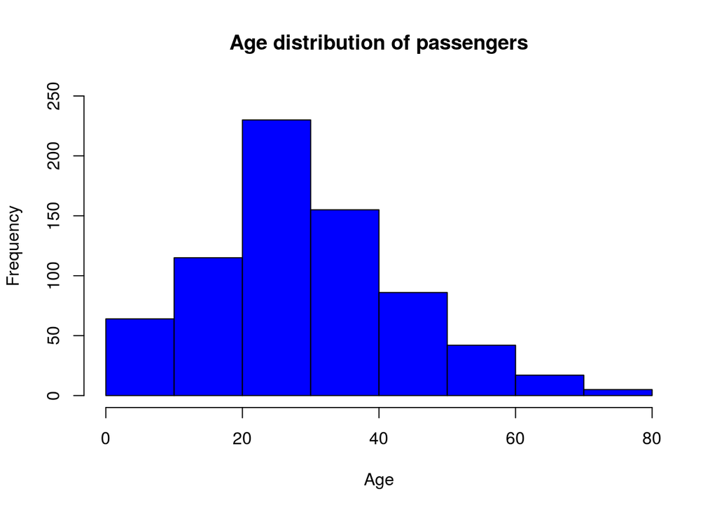

```r
hist(inputdata$Age,
     main="Age distribution of passengers",
     xlab="Age",col="blue", ylim=c(0,250))
```

Question 4: How many passengers were in each class?

Go to relevant chunk of code, highlight and execute!

```r
table(inputdata$Pclass)
```

```
##
##   1   2   3
## 186 173 355
```

Advanced Analytics

We have been asked to find patterns for the passengers that survived vs. those that pasrished. We can already make assumptions on which of the features predcit better the survival rate. What do you think? Which of the features is better for predicting survival?

[figure not shown]

As data scientists, we are already thinking of the many possible ways we can asnwer this question. Today we will try two machine learning methods.

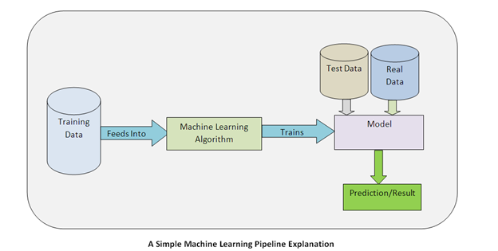

Logistic Regression

Run logistic regression

Let’s go back to our R script and execute the relevant code. In the first few lines, we are splitting our data set in training and test and then we are using the glm function to run our analysis.

```r
# Split data in training and test sets
set.seed(31415) # Always set the seed so you can replicate data if necessary
index <- 1:nrow(inputdata)
testindex <- sample(index, .2*trunc(length(index))) # Split data in 80% training, 20% test
testset <- inputdata[testindex,] # test set
trainset <- inputdata[-testindex,] # train set

# Logistic regression
mylogit <- glm(Survived ~ Sex + Fare + Age + Pclass + SibSp,
               data = trainset, family="binomial")

# Summary of results
summary(mylogit)
```

```
##
## Call:
## glm(formula = Survived ~ Sex + Fare + Age + Pclass + SibSp, family = "binomial",
##     data = trainset)
##
## Deviance Residuals:
##     Min       1Q   Median       3Q      Max
## -2.9428  -0.5923  -0.3391   0.5833   2.4647
##
## Coefficients:
##              Estimate Std. Error z value Pr(>|z|)
## (Intercept)  5.734955   0.713636   8.036 9.26e-16 ***
## Sexmale     -2.851662   0.252111 -11.311  < 2e-16 ***
## Fare         0.003015   0.002906   1.037 0.299544
## Age         -0.046109   0.009538  -4.834 1.34e-06 ***
## Pclass      -1.273658   0.187563  -6.791 1.12e-11 ***
## SibSp       -0.509379   0.149174  -3.415 0.000639 ***
## ---
## Signif. codes:  0 '***' 0.001 '**' 0.01 '*' 0.05 '.' 0.1 ' ' 1
##
## (Dispersion parameter for binomial family taken to be 1)
##
##     Null deviance: 776.77  on 571  degrees of freedom
## Residual deviance: 489.06  on 566  degrees of freedom
## AIC: 501.06
##
## Number of Fisher Scoring iterations: 5
```

Below we can see the output of this analysis. There are two things that we should focus on. The more asterisks we see next to a feature the more significant it is for predicting survival. What we see is that a passenger’s class, their gender, age and if they were travelling with siblings are the most significant factors.

Decision tree

Run decision tree.

```r
library(rpart)
library(rpart.plot)
# Set model parameters
Min_num_splits <- 100 #Minimal number of items required to search for split
Min_bucket     <- floor(Min_num_splits/3) #Minimal number of items per bucket
Max_depth      <- 10 #Maximum depth of final tree

# Decision tree
mytree <- rpart(Survived ~ Sex + Fare + Age + Pclass + SibSp
                , data=trainset
                , control = rpart.control(minsplit  = Min_num_splits,
                                          minbucket = Min_bucket,
                                          maxdepth  = Max_depth))
```

[figure not shown]

[figure not shown]

[figure not shown]

```r
# Decision tree Visualisation
prp(mytree,
    main = "Titanic Survival Tree",     #Title
    type = 4, fallen = T, branch = 1, clip.right.labs = F,
    under.cex = 1, box.palette = "-GnYlRd", extra = 101,
    branch.col="gray", under = T, lt = " < ", ge = " >= ")
```

Compare models

```r
trainset$logit_prediction <- ifelse(predict(mylogit, trainset, type='response')>=0.5, 1, 0)
logittable<- table(trainset$logit_prediction,trainset$Survived)
logittable
```

```
##
##       0   1
##   0 289  61
##   1  45 177
```

```r
# Decision tree onfusion maatrix
trainset$tree_prediction <- ifelse( predict(mytree,trainset)>=0.5, 1, 0)
treetable<- table(trainset$tree_prediction,trainset$Survived)
treetable
```

```
##
##       0   1
##   0 290  75
##   1  44 163
```

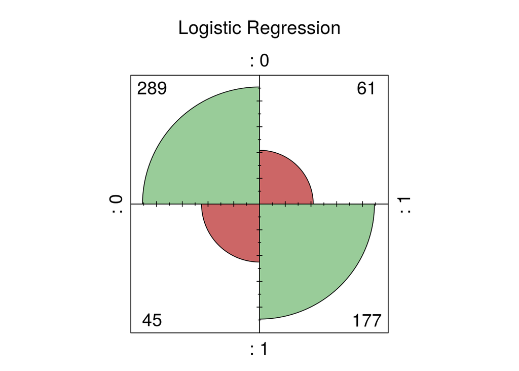

```r
# Plot confusion maatrix for logistic regression
fourfoldplot(logittable, color = c("#CC6666", "#99CC99"),
conf.level = 0, margin = 1, main = "Logistic Regression")
```

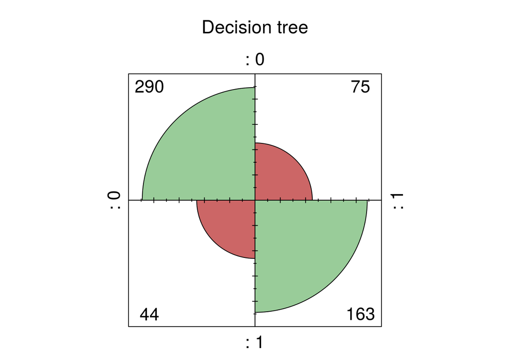

```r
# Plot confusion maatrix for decision tree
fourfoldplot(treetable, color = c("#CC6666", "#99CC99"),
conf.level = 0, margin = 1, main = "Decision tree")
```

Great job. We survived!